# Data_Analysis_4

2024-03-15

[output not shown]

# Data Analysis 4

Identifying discharge rates for batteries used for SPO2SENSOR devices:

Acceptable for SPO2SENSOR Clustering Analysis: 44-4b-5d-01-04-29, 44-4b-5d-01-04-91, 44-4b-5d-01-04-09, 44-4b-5d-01-04-89, 44-4b-5d-01-04-21, 44-4b-5d-01-04-11, 44-4b-5d-01-04-31, 44-4b-5d-01-04-39, 44-4b-5d-01-04-01, 44-4b-5d-01-04-79, 44-4b-5d-01-04-81, 44-4b-5d-01-04-01, 44-4b-5d-01-04-19, 44-4b-5d-01-04-51

No SPO2SENSOR Devices - 44-4b-5d-01-04-a1, 44-4b-5d-01-04-41, 44-4b-5d-01-04-b1

```r
spo2_filtered_df = clustered_df %>%
  filter(hostName %in% c("44-4b-5d-01-04-29", "44-4b-5d-01-04-91", "44-4b-5d-01-04-09", "44-4b-5d-01-04-89", "44-4b-5d-01-04-21", "44-4b-5d-01-04-11", "44-4b-5d-01-04-31", "44-4b-5d-01-04-39", "44-4b-5d-01-04-01", "44-4b-5d-01-04-79", "44-4b-5d-01-04-81", "44-4b-5d-01-04-01", "44-4b-5d-01-04-19"," 44-4b-5d-01-04-51"), device == "SPO2SENSOR") %>%
  group_by(hostName, jump_cluster) %>%
  summarize(diff_cap = max(capacity) - min(capacity),
            mins = as.numeric(difftime(max(timestamp), min(timestamp), units = "mins"))) %>%
  mutate(discharge_rate = diff_cap/mins) %>%
  filter(discharge_rate != 0)
```

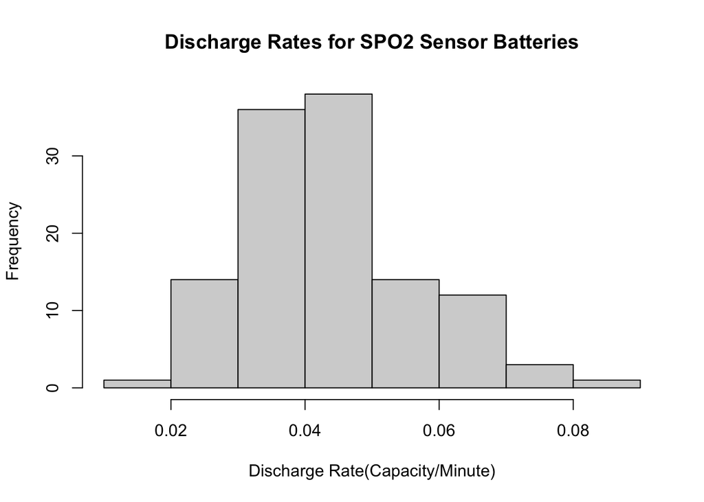

```r
hist(spo2_filtered_df$discharge_rate, main = "Discharge Rates for SPO2 Sensor Batteries", xlab = "Discharge Rate(Capacity/Minute)", ylab = "Frequency")
```

```r
summary(spo2_filtered_df$discharge_rate)
```

```
##    Min. 1st Qu.  Median    Mean 3rd Qu.    Max.
## 0.01993 0.03367 0.04186 0.04361 0.05007 0.08607
```

Valid: 44-4b-5d-01-04-29, 44-4b-5d-01-04-91, 44-4b-5d-01-04-09, 44-4b-5d-01-04-51, 44-4b-5d-01-04-21, 44-4b-5d-01-04-11, 44-4b-5d-01-04-81, 44-4b-5d-01-04-31, 44-4b-5d-01-04-39, 44-4b-5d-01-04-19, 44-4b-5d-01-04-79, 44-4b-5d-01-04-01

No RESP devices: 44-4b-5d-01-04-41, 44-4b-5d-01-04-a1, 44-4b-5d-01-04-b1

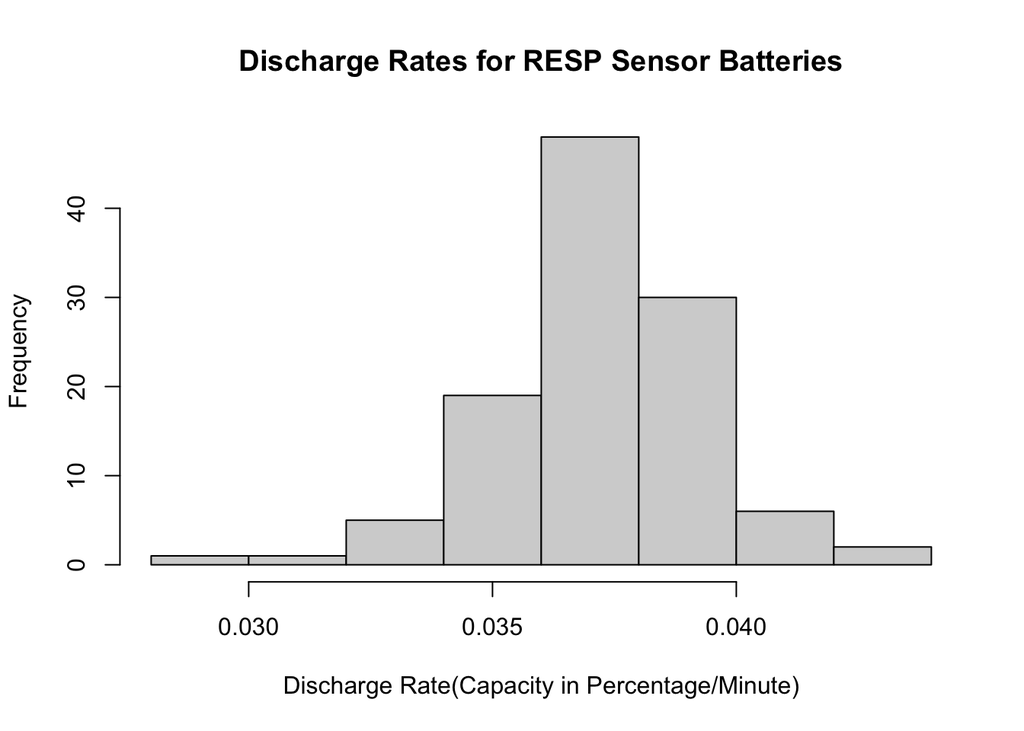

```r
hist(resp_filtered_df$discharge_rate, main = "Discharge Rates for RESP Sensor Batteries", xlab = "Discharge Rate(Capacity in Percentage/Minute)", ylab = "Frequency")
```

```r
summary(resp_filtered_df$discharge_rate)
```

```
##    Min. 1st Qu.  Median    Mean 3rd Qu.    Max.
## 0.02966 0.03616 0.03726 0.03716 0.03849 0.04285
```

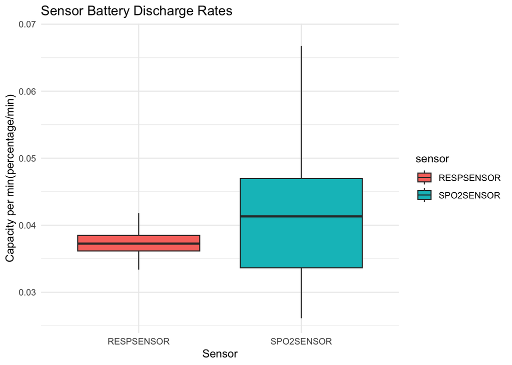

$H_o:$ The distribution of Discharge Rates of SPO2 Device Batteries is the same as the distribution of Discharge Rate of Resp Device Batteries

$H_a:$ The distribution of Discharge Rates of SPO2 Device Batteries is greater than the distribution of Discharge Rate of Resp Device Batteries

Removing Outliers:

```r
q1 <- quantile(spo2_filtered_df$discharge_rate, 0.25)
q3 <- quantile(spo2_filtered_df$discharge_rate, 0.75)
iqr <- q3 - q1

lower_bound <- q1 - 1.5 * iqr
upper_bound <- q3 + 1.5 * iqr

spo2_filtered_df <- spo2_filtered_df %>%
  filter(discharge_rate >= lower_bound, discharge_rate <= upper_bound)
```

```r
q1 <- quantile(resp_filtered_df$discharge_rate, 0.25)
q3 <- quantile(resp_filtered_df$discharge_rate, 0.75)
iqr <- q3 - q1

lower_bound <- q1 - 1.5 * iqr
upper_bound <- q3 + 1.5 * iqr

resp_filtered_df <- resp_filtered_df %>%
  filter(discharge_rate >= lower_bound, discharge_rate <= upper_bound)
```

Normality Assumption:

```r
require(car)
```

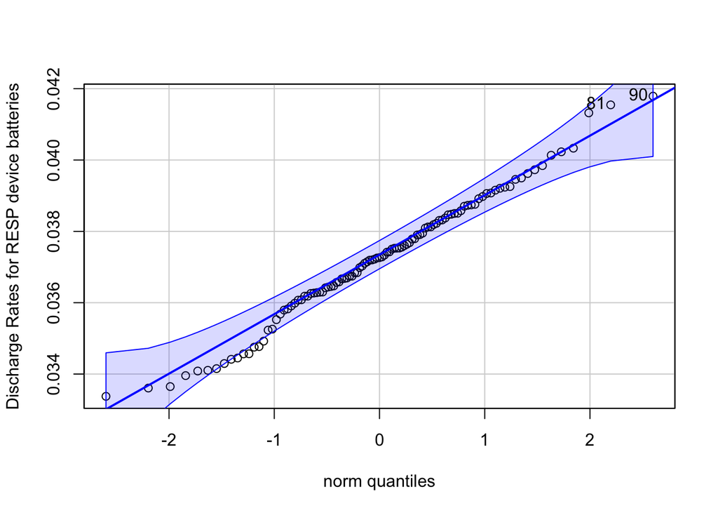

```
## [1] 90 81
```

```r
qqPlot(resp_filtered_df$discharge_rate, ylab = "Discharge Rates for RESP device batteries")
```

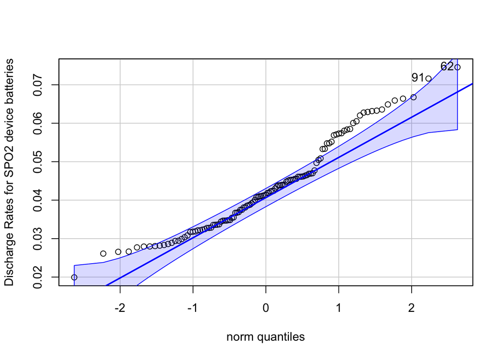

```
## [1] 62 91
```

```r
require(car)
qqPlot(spo2_filtered_df$discharge_rate, ylab = "Discharge Rates for SPO2 device batteries")
```

Equal Shape and Spread:

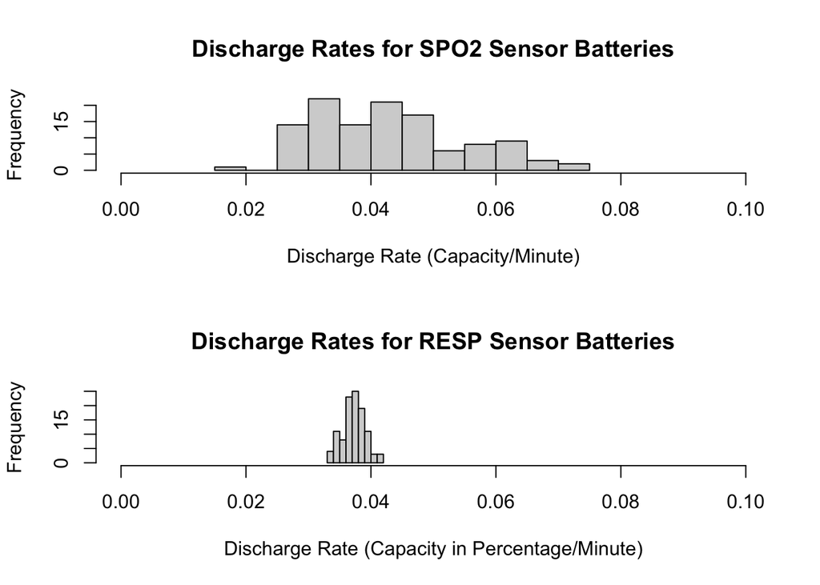

```r
par(mfrow = c(2, 1))

hist(spo2_filtered_df$discharge_rate, main = "Discharge Rates for SPO2 Sensor Batteries", xlab = "Discharge Rate (Capacity/Minute)", ylab = "Frequency", xlim = c(0, 0.1))

hist(resp_filtered_df$discharge_rate, main = "Discharge Rates for RESP Sensor Batteries", xlab = "Discharge Rate (Capacity in Percentage/Minute)", ylab = "Frequency", xlim = c(0, 0.1))
```

Equal Variance Assumption:

```r
(s_s = sd(spo2_filtered_df$discharge_rate))
```

```
## [1] 0.01164306
```

```r
(s_r = sd(resp_filtered_df$discharge_rate))
```

```
## [1] 0.001791995
```

```r
(s_s/s_r)
```

```
## [1] 6.49726
```

$\frac{\sigma_s}{\sigma_r} = \frac{0.01164306}{0.001791995} = 6.49726$

```r
wilcox.test(spo2_filtered_df$discharge_rate, resp_filtered_df$discharge_rate, mu = 0, alternative = "greater")
```

```
##
##  Wilcoxon rank sum test with continuity correction
##
## data:  spo2_filtered_df$discharge_rate and resp_filtered_df$discharge_rate
## W = 7985, p-value = 0.0001851
## alternative hypothesis: true location shift is greater than 0
```